# STA 141A Project

Filip Wilhelm Sjostrand

2023-03-22

```r
# Packages ----------
library(dplyr)
library(readr)
library(viridis)
library(ggplot2)
library(maps)
library(ggthemes)
library(mapproj)
library(readxl)
```

# Exercise I

## a)

```r
# Get Data ----------
us <- data.frame(read_csv(
  "~/Documents/UC Davis/Courses/STA 141A/Proj/us.csv",
  col_types = cols(
    date = col_date(format = "%Y-%m-%d"),
    cases = col_integer(),
    deaths = col_integer()
    )
  ))
```

```r
# Daily and average values ----------
us["new_cases"] <- stats::filter(
  us$cases,
  c(1, -1),
  method = "convolution",
  sides = 1
  )
us["new_deaths"] <- stats::filter(
  us$deaths, c(1, -1),
  method = "convolution",
  sides = 1
  )
us["avg_new_cases"] <- stats::filter(
  us$new_cases,
  rep(1/7, 7),
  method = "convolution",
  sides = 1
  )
us["avg_new_deaths"] <- stats::filter(
  us$new_deaths,
  rep(1/7, 7),
  method = "convolution",
  sides = 1
  )
```

## b)

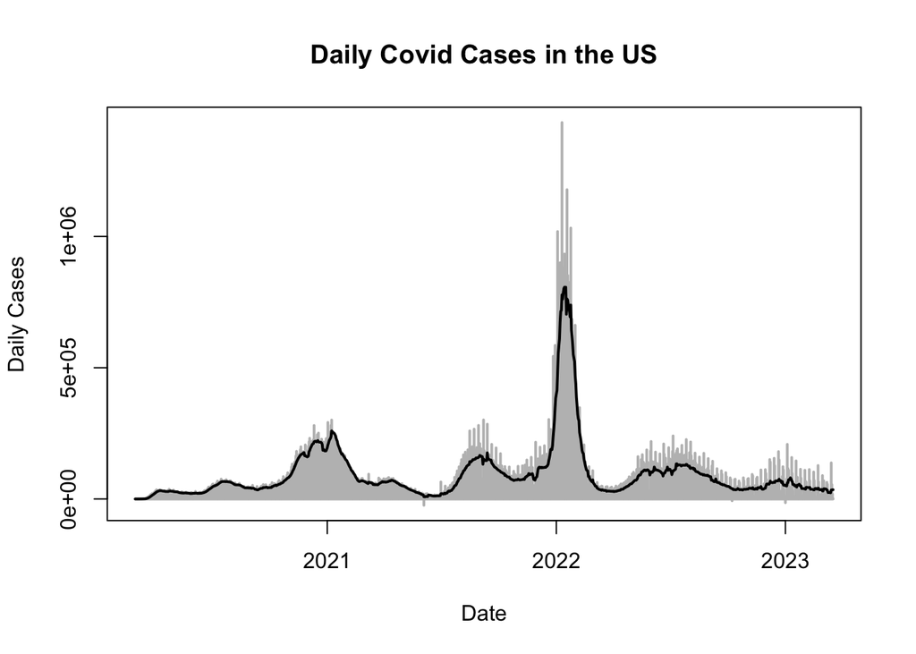

```r
# Daily cases plot ----------
plot(
  new_cases ~ date,
  data = us,
  type = "h",
  col = "gray",
  subset = date >= "2020-03-01",
  lwd = 2,
  ylab = "Daily Cases",
  xlab = "Date",
  main = "Daily Covid Cases in the US"
  )
lines(avg_new_cases ~ date, data = us, subset = date >= "2020-03-01", lwd = 2)
```

We can observe two more pronounced spikes: in the transition from 2020 to 2021 and 2021 to 2022. The most significant spike occurred at the beginning of 2022.

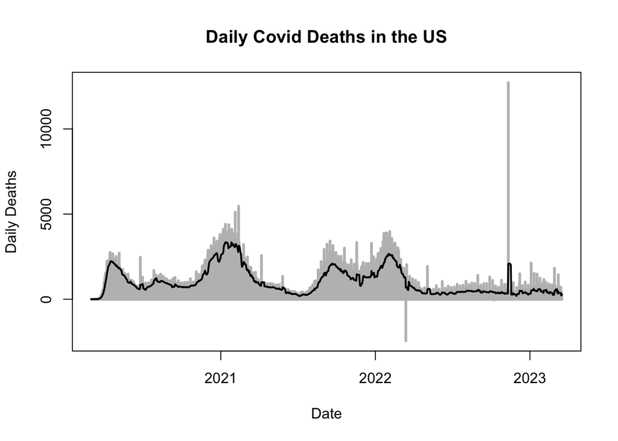

```r
# Daily death plot ----------
plot(
  new_deaths ~ date,
  data = us,
  type = "h",
  col = "gray",
  subset = date >= "2020-03-01",
  lwd = 3,
  ylab = "Daily Deaths",
  xlab = "Date",
  main = "Daily Covid Deaths in the US"
  )
lines(avg_new_deaths ~ date, data = us, subset = date >= "2020-03-01", lwd = 2)
```

The daily deaths are relatively constant. However, we observe three peaks. First, at the start of the pandemic, we saw a significant increase, which is not an anomaly since the people most receptive to severe sickness got struck before proper measures were taken. The second and third peaks coincided with the first and second daily case peaks. Given an increase in cases, it is expected to see an increase in deaths.

There are two significant anomalies to consider. First, we have a considerable negative value in early 2022 and an enormous positive value in late 2022. Since it is not possible to have negative deaths, nor any indication of increased cases around the largely positive, we can only assume that they occurred due to sampling errors or corrections.

# Exercise II

## a)

```r
# Get data ----------
us_states <- data.frame(read_csv(
  "~/Documents/UC Davis/Courses/STA 141A/Proj/us-states.csv",
  col_types = cols(
    date = col_date(format = "%Y-%m-%d"),
    cases = col_integer(),
    deaths = col_integer()
    )
  ))
```

## b)

```r
# Californian cases and deaths ----------
california <- subset(us_states, state == "California")

# Daily and average values ----------
california["new_cases"] <- stats::filter(
  california$cases,
  c(1, -1),
  method = "convolution",
  sides = 1
  )
california["new_deaths"] <- stats::filter(
  california$deaths,
  c(1, -1),
  method = "convolution",
  sides = 1
  )
california["avg_new_cases"] <- stats::filter(
  california$new_cases,
  rep(1/7, 7),
  method = "convolution",
  sides = 1
  )
california["avg_new_deaths"] <- stats::filter(
  california$new_deaths,
  rep(1/7, 7),
  method = "convolution",
  sides = 1
  )
```

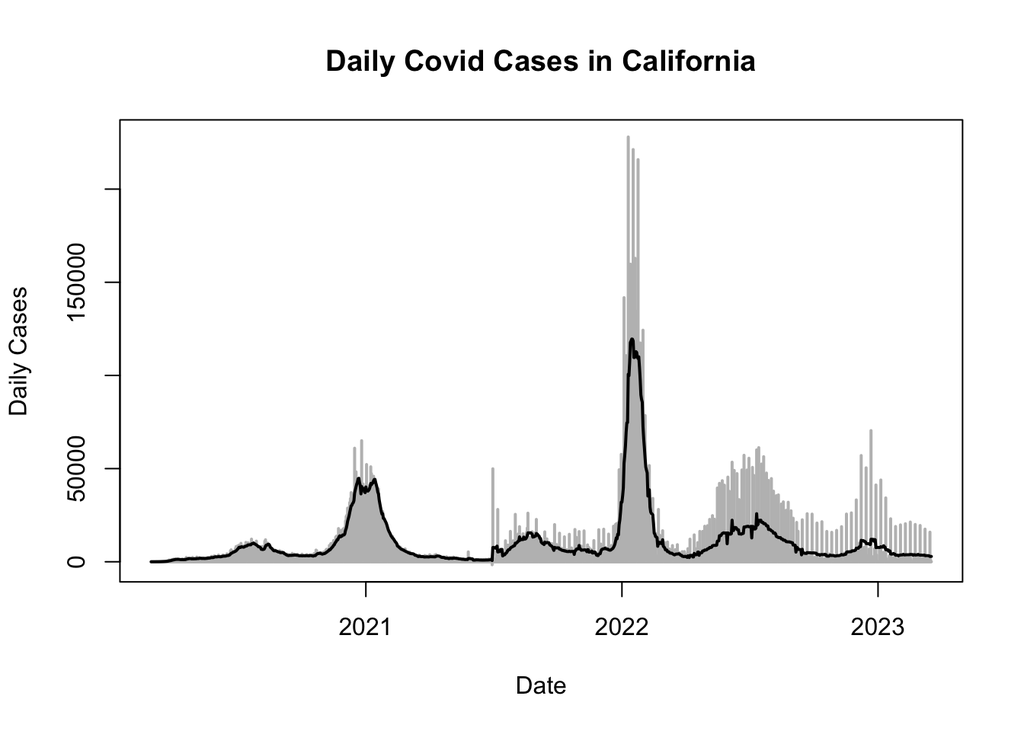

```r
# Daily cases plot ----------
plot(
  new_cases ~ date,
  data = california,
  type = "h",
  col = "gray",
  subset = date >= "2020-03-01",
  lwd = 2,
  ylab = "Daily Cases",
  xlab = "Date",
  main = "Daily Covid Cases in California"
  )
lines(
  avg_new_cases ~ date,
  data = california,
  subset = date >= "2020-03-01",
  lwd = 2
  )
```

California generally follows a similar progression to the US, albeit with fewer peaks. Given a more considerable difference between the daily cases and the 7-day average than in the overall US plot, we can conclude a more considerable variance in the data.

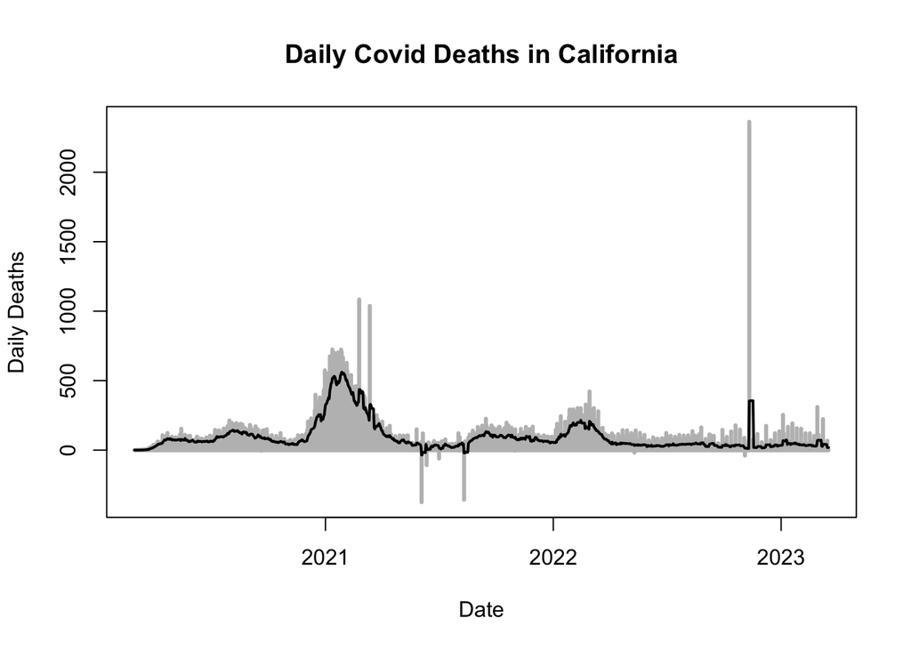

```r
# Daily death plot ----------
plot(
  new_deaths ~ date,
  data = california,
  type = "h",
  col = "gray",
  subset = date >= "2020-03-01",
  lwd = 3,
  ylab = "Daily Deaths",
  xlab = "Date",
  main = "Daily Covid Deaths in California"
  )
lines(
  avg_new_deaths ~ date,
  data = california,
  subset = date >= "2020-03-01",
  lwd = 2
  )
```

What is noticeable is that California experienced much fewer deaths at the start of the pandemic and the second peak. A possible reason is a greater vaccine rate than the rest of the country. Another could be greater trust in the institutions and governance, thus, following guidelines to a greater extent. Here, we also observe large daily and negative death value anomalies, probably due to the cause previously mentioned.

# Exercise III

## a)

```r
# Get data and tidy ---------
us_counties <- data.frame(read_csv(
  "~/Documents/UC Davis/Courses/STA 141A/Proj/us-counties.csv",
  col_types = cols(
    date = col_date(format = "%Y-%m-%d"),
    cases = col_integer(),
    deaths = col_integer())
  ))
us_counties_2022 <- data.frame(read_csv(
  "~/Documents/UC Davis/Courses/STA 141A/Proj/us-counties-2022.csv",
  col_types = cols(
    date = col_date(format = "%Y-%m-%d"),
    cases = col_integer(),
    deaths = col_integer())
  ))
us_counties_2023 <- data.frame(read_csv(
  "~/Documents/UC Davis/Courses/STA 141A/Proj/us-counties-2023.csv",
  col_types = cols(
    date = col_date(format = "%Y-%m-%d"),
    cases = col_integer(),
    deaths = col_integer())
  ))

yolo <- subset(us_counties, county == "Yolo")
yolo2022 <- subset(us_counties_2022, county == "Yolo")
yolo2023 <- subset(us_counties_2023, county == "Yolo")

yolo <- yolo %>%
  rbind(yolo2022, yolo2023) %>%
  distinct(date, .keep_all = T)

# Daily and average values ----------
yolo["new_cases"] <- stats::filter(
  yolo$cases,
  c(1, -1),
  method = "convolution",
  sides = 1
  )
yolo["avg_new_cases"] <- stats::filter(
  yolo$new_cases,
  rep(1/7, 7),
  method = "convolution",
  sides = 1
  )
```

## b)

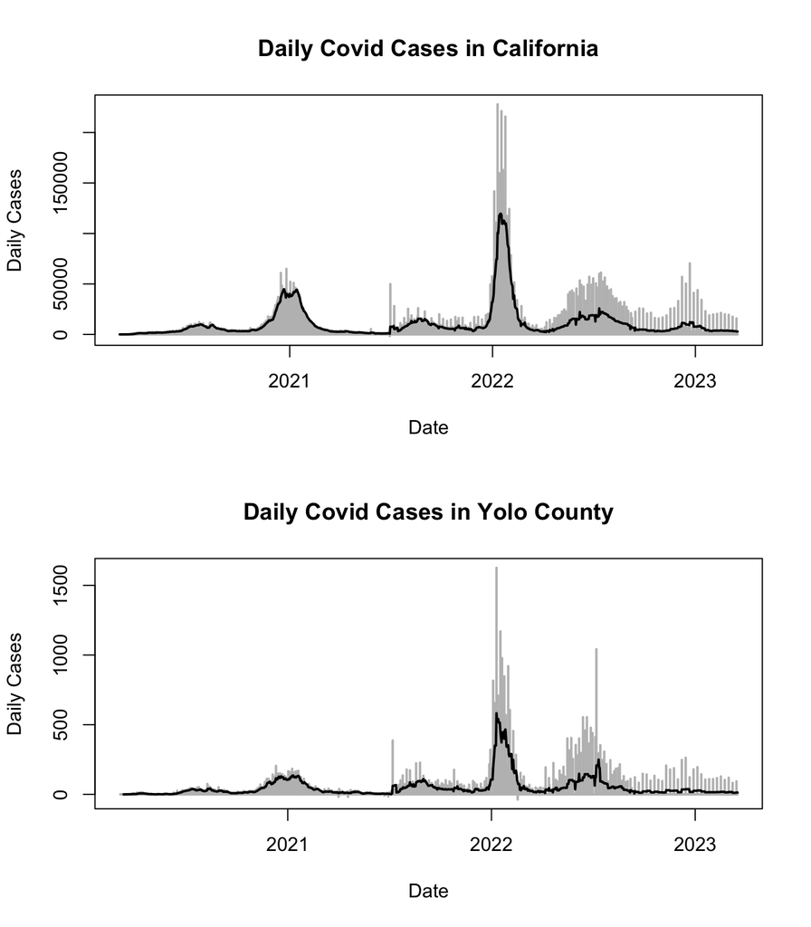

```r
# Daily cases plot ----------
par(mfrow=c(2,1))
plot(
  new_cases ~ date,
  data = california,
  type = "h",
  col = "gray",
  subset = date >= "2020-03-01",
  lwd = 2,
  ylab = "Daily Cases",
  xlab = "Date",
  main = "Daily Covid Cases in California"
  )
lines(
  avg_new_cases ~ date,
  data = california,
  subset = date >= "2020-03-01",
  lwd = 2
  )

plot(
  new_cases ~ date,
  data = yolo,
  type = "h",
  col = "gray",
  subset = date >= "2020-03-01",
  lwd = 2,
  ylab = "Daily Cases",
  xlab = "Date",
  main = "Daily Covid Cases in Yolo County"
  )
lines(avg_new_cases ~ date, data = yolo, subset = date >= "2020-03-01", lwd = 2)
```

## Question

**What do you notice when comparing the plot of daily new cases in Yolo county to the analogous plot for the state of California as a whole? What might explain what you are seeing?**

We observe that Yolo county follows a similar development as the state of California does in general. In the graph, California and Yolo have a somewhat flat curve up until the end of 2020, peaking in early 2021, then declining back to a flatter curve in the spring of 2021. A probable cause of such development is that in the earlier days of the pandemic, more people were prone to following guidelines, i.e., staying home, practicing social distancing, and using face masks. Hence, causation to a peak lower than the forthcoming ones. We also know that the virus has seasonal leverage—like the common flu—where it is more prone to infect and spread during the winter half of the year. Thus we should expect a higher peak in the colder months, as observed. Finally, vaccinations started around April in the US, which could also significantly influence the prolonged flattening of the curve until early 2022.

# Excercise III: Bonus

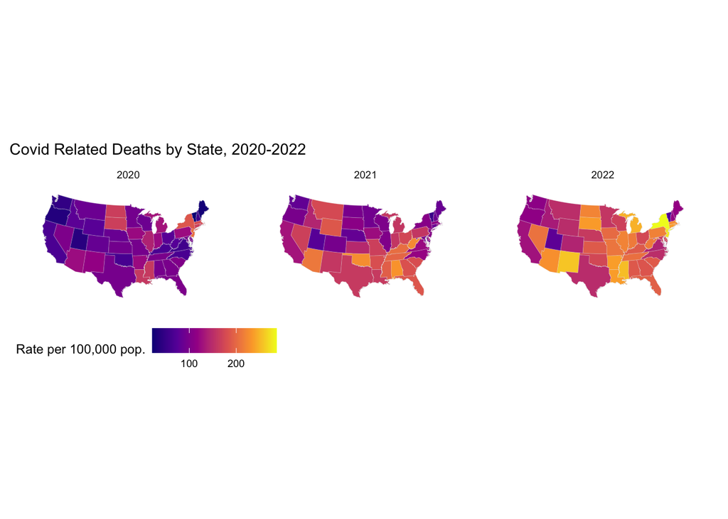

```r
# Get and tidy data ----------
population <- read_excel(
  "~/Documents/UC Davis/Courses/STA 141A/Proj/NST-EST2022-POP.xlsx",
  skip = 3
  )
population$state <-  sub('.', '', population$state)

# Yearly state deaths ----------
us_states["year"] <- format(as.Date(us_states$date, format="%Y-%m-%d"),"%Y")

cumulative_deaths <- us_states %>%
  group_by(year, state) %>%
  summarise(deaths = max(deaths))

deaths_2020 <- cumulative_deaths %>%
  filter(year == 2020) %>%
  left_join((population %>% select(state, `2020`))) %>%
  rename(population = `2020`) %>%
  mutate(death_capita = deaths/population*100000)

deaths_2021 <- cumulative_deaths %>%
  filter(year == 2021) %>%
  left_join((deaths_2020 %>% select(state, deaths)), by = "state") %>%
  transmute(year = year.x, state = state, deaths = deaths.x - deaths.y) %>%
  left_join((population %>% select(state, `2021`))) %>%
  rename(population = `2021`) %>%
  mutate(death_capita = deaths/population*100000)

deaths_2022 <- cumulative_deaths %>%
  filter(year == 2022) %>%
  left_join((deaths_2021 %>% dplyr::select(state, deaths)), by = "state") %>%
  transmute(year = year, state = state, deaths = deaths.x - deaths.y) %>%
  left_join((population %>% select(state, `2022`))) %>%
  rename(population = `2022`) %>%
  mutate(death_capita = deaths/population*100000)

deaths <- rbind(deaths_2020, deaths_2021, deaths_2022)

# State Map ----------
states <- map_data("state")
deaths$region <- tolower(deaths$state)
deaths_map <- left_join(states, deaths, by = "region")

p0 <- ggplot(
  data = deaths_map,
  mapping = aes(
    x = long,
    y = lat,
    group = group,
    fill = death_capita
    )
  )

p1 <- p0 +
  geom_polygon(color = "gray90", size = 0.05) +
  coord_map(projection = "albers", lat0 = 39, lat1 = 45)

p2 <- p1 + scale_fill_viridis_c(option = "plasma")

p2 +
  theme_map() +
  facet_wrap(~ year, ncol = 3) +
  theme(
    legend.position = "bottom",
    strip.background = element_blank()
    ) +
  labs(
    fill = "Rate per 100,000 pop.",
    title = "Covid Related Deaths by State, 2020-2022"
    )
```

The plot above shows the development of Covid-related deaths from 2020-2022. We can conclude that in each state, an increase in deaths occurred. However, specific states performed better than others. For instance, Utah maintained a reasonably low death rate compared to the rest of the country, whereas New York and New Jersey saw significant increases. A probable cause could be that Utah is a rural state while the other two have a dense population.

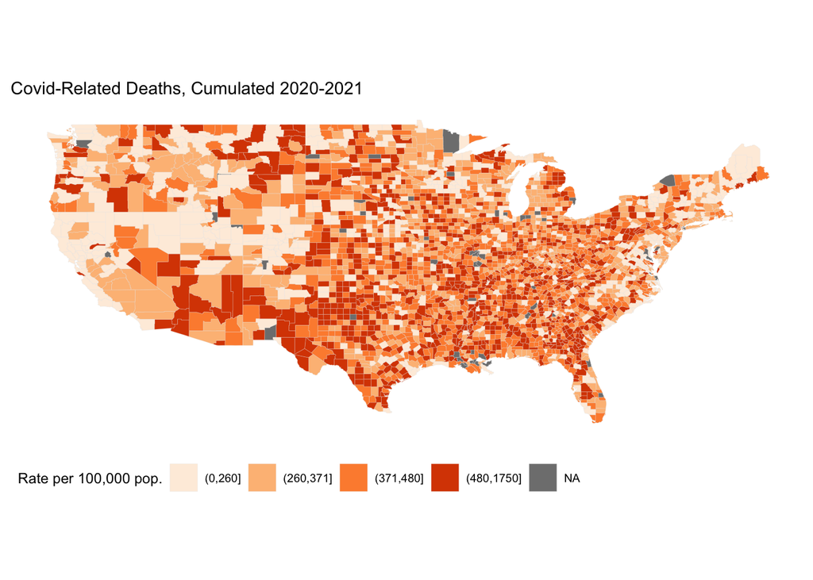

```r
# Add county population ----------
county_population <- read_csv(
  "~/Documents/UC Davis/Courses/STA 141A/Proj/co-est2021-alldata.csv"
  )

pops <- county_population %>%
  select(STATE, COUNTY, STNAME, CTYNAME, POPESTIMATE2021) %>%
  mutate(fips = paste(STATE, COUNTY, sep="")) %>%
  select(fips, POPESTIMATE2021)

county_data <- us_counties %>%
  group_by(fips, county) %>%
  summarise(cumulated_deaths = max(deaths)) %>%
  left_join(pops, by = "fips") %>%
  mutate(death_capita = cumulated_deaths/POPESTIMATE2021*100000) %>%
  mutate(subregion = tolower(county))

# Create Factor ----------
county_data$interval <- as.factor(cut(
  county_data$death_capita,
  quantile(county_data$death_capita, na.rm = T)))

fltr <- levels(county_data$interval)=="(480,1.75e+03]"
levels(county_data$interval)[fltr] <- "(480,1750]"

# Map
county_map <- map_data("county")
county_full <- left_join(county_map, county_data,  by = "subregion")

death_p <- ggplot(
  data = county_full,
  mapping = aes(
    x = long,
    y = lat,
    fill = interval,
    group = group
    )
  )

death_p1 <- death_p +
  geom_polygon(color = "gray90", size = 0.05) +
  coord_equal()

death_p2 <- death_p1 +
  scale_fill_manual(values = RColorBrewer::brewer.pal(n = 4, name = "Oranges"))

death_p2 +
  labs(
    title = "Covid-Related Deaths, Cumulated 2020-2021",
    fill = "Rate per 100,000 pop.") +
  theme_map() +
  theme(legend.position = "bottom")
```